# PracticaalMachineLearning Course Project

Jamaluddeen Muhammad

11/7/2020

## INTRODUCTION

In this project, data from accelerometers on the belt, forearm, arm, and dumbell of 6 participants is to be used. The participants were asked to perform one set of 10 repetitions of the Unilateral Dumbbell Biceps Curl in five different fashions: exactly according to the specification (Class A), throwing the elbows to the front (Class B), lifting the dumbbell only halfway (Class C), lowering the dumbbell only halfway (Class D) and throwing the hips to the front (Class E). The data for this project come from this source: http://groupware.les.inf.puc-rio.br/har The goal of the project is to predict the manner in which they did the exercise.

## DATA LOADING AND PROCESSING

The training data for this project are available [here] (https://d396qusza40orc.cloudfront.net/predmachlearn/pml-training.csv) while the test data are available [here] (https://d396qusza40orc.cloudfront.net/predmachlearn/pml-testing.csv)

The training and testing csv files were downloaded and were viewed. It was noticed that missing values were marked as NA, blank, or #DIV/0!, 1ST to 7th raw were not usefull as such will be removed.

```r
train <- read.csv("~/pml-training.csv", na.strings = c("NA", "", "#DIV/0!"))
test <- read.csv("~/pml-testing.csv", na.strings = c("NA", "", "#DIV/0!"))

traindata <- train[, -c(1:7)] # removing 1st 7 columns
testdata <- test[, -c(1:7)] # removing 1st 7 columns
training <- traindata[,which(colSums(is.na(traindata)) == 0)]
testing <- testdata[,which(colSums(is.na(testdata)) == 0)]
```

```r
library(caret)
library(rpart)
library(randomForest)
library(rattle)
```

## CROSS VALIDATION

Cross validation will be done by splitting the training into 70% trainset, and 30% testset.

```r
inTrain <- createDataPartition(training$classe, p=0.7, list=FALSE)
trainset <- training[inTrain,]
testset <- training[-inTrain,]
```

## MODELLING

### Decision Tree Model Training and Test

```r
modfitDT <- train(classe ~.,  data=trainset, method="rpart")
predictDT <- predict(modfitDT, newdata=testset)
print(modfitDT$finalModel)
```

```
## n= 13737
##
## node), split, n, loss, yval, (yprob)
##       * denotes terminal node
##
##  1) root 13737 9831 A (0.28 0.19 0.17 0.16 0.18)
##    2) roll_belt< 130.5 12573 8679 A (0.31 0.21 0.19 0.18 0.11)
##      4) pitch_forearm< -33.95 1102    6 A (0.99 0.0054 0 0 0) *
##      5) pitch_forearm>=-33.95 11471 8673 A (0.24 0.23 0.21 0.2 0.12)
##       10) magnet_dumbbell_y< 426.5 9567 6848 A (0.28 0.18 0.24 0.19 0.11)
##         20) roll_forearm< 122.5 5935 3501 A (0.41 0.18 0.19 0.16 0.058) *
##         21) roll_forearm>=122.5 3632 2440 C (0.078 0.18 0.33 0.23 0.18) *
##       11) magnet_dumbbell_y>=426.5 1904  977 B (0.041 0.49 0.047 0.23 0.19) *
##    3) roll_belt>=130.5 1164   12 E (0.01 0 0 0 0.99) *
```

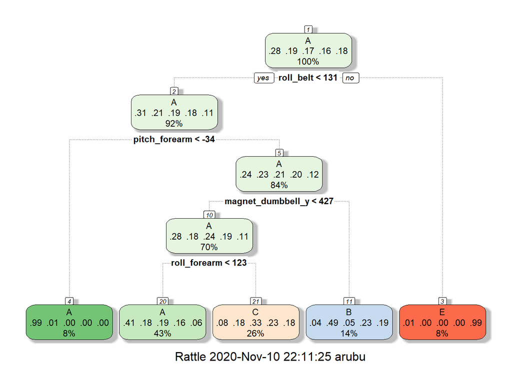

```r
fancyRpartPlot(modfitDT$finalModel)
```

```r
confusionMatrix(predictDT, as.factor(testset$classe))
```

```
## Confusion Matrix and Statistics
##
##           Reference
## Prediction    A    B    C    D    E
##          A 1513  445  453  439  153
##          B   44  421   40  174  163
##          C  115  273  533  351  287
##          D    0    0    0    0    0
##          E    2    0    0    0  479
##
## Overall Statistics
##
##                Accuracy : 0.5006
##                  95% CI : (0.4877, 0.5135)
##     No Information Rate : 0.2845
##     P-Value [Acc > NIR] : < 2.2e-16
##
##                   Kappa : 0.348
##
##  Mcnemar's Test P-Value : NA
##
## Statistics by Class:
##
##                      Class: A Class: B Class: C Class: D Class: E
## Sensitivity            0.9038  0.36962  0.51949   0.0000  0.44270
## Specificity            0.6462  0.91129  0.78885   1.0000  0.99958
## Pos Pred Value         0.5038  0.50000  0.34189      NaN  0.99584
## Neg Pred Value         0.9441  0.85762  0.88604   0.8362  0.88842
## Prevalence             0.2845  0.19354  0.17434   0.1638  0.18386
## Detection Rate         0.2571  0.07154  0.09057   0.0000  0.08139
## Detection Prevalence   0.5103  0.14308  0.26491   0.0000  0.08173
## Balanced Accuracy      0.7750  0.64046  0.65417   0.5000  0.72114
```

### Random Forest model

```r
modfitRF <- train(classe ~.,  data=trainset, method="rf", ntree=500)
predictRF <- predict(modfitRF, newdata=testset)
print(modfitRF$finalModel)
```

```
##
## Call:
##  randomForest(x = x, y = y, ntree = 500, mtry = param$mtry)
##                Type of random forest: classification
##                      Number of trees: 500
## No. of variables tried at each split: 27
##
##         OOB estimate of  error rate: 0.66%
## Confusion matrix:
##      A    B    C    D    E class.error
## A 3901    2    2    0    1 0.001280082
## B   20 2634    3    1    0 0.009029345
## C    0   11 2376    9    0 0.008347245
## D    0    1   26 2222    3 0.013321492
## E    0    0    5    7 2513 0.004752475
```

```r
confusionMatrix(predictRF, as.factor(testset$classe))
```

```
## Confusion Matrix and Statistics
##
##           Reference
## Prediction    A    B    C    D    E
##          A 1674   16    0    0    0
##          B    0 1122    7    0    1
##          C    0    1 1013    8    3
##          D    0    0    6  956    2
##          E    0    0    0    0 1076
##
## Overall Statistics
##
##                Accuracy : 0.9925
##                  95% CI : (0.99, 0.9946)
##     No Information Rate : 0.2845
##     P-Value [Acc > NIR] : < 2.2e-16
##
##                   Kappa : 0.9905
##
##  Mcnemar's Test P-Value : NA
##
## Statistics by Class:
##
##                      Class: A Class: B Class: C Class: D Class: E
## Sensitivity            1.0000   0.9851   0.9873   0.9917   0.9945
## Specificity            0.9962   0.9983   0.9975   0.9984   1.0000
## Pos Pred Value         0.9905   0.9929   0.9883   0.9917   1.0000
## Neg Pred Value         1.0000   0.9964   0.9973   0.9984   0.9988
## Prevalence             0.2845   0.1935   0.1743   0.1638   0.1839
## Detection Rate         0.2845   0.1907   0.1721   0.1624   0.1828
## Detection Prevalence   0.2872   0.1920   0.1742   0.1638   0.1828
## Balanced Accuracy      0.9981   0.9917   0.9924   0.9950   0.9972
```

### LDA

```r
modfitLDA <- train(classe ~.,  data=trainset, method="lda")
predictLDA <- predict(modfitLDA, newdata=testset)
print(modfitLDA$finalModel)
```

[output not shown]

[output cut: 78 more lines]

[output not shown]

```r
confusionMatrix(predictLDA, as.factor(testset$classe))
```

```
## Confusion Matrix and Statistics
##
##           Reference
## Prediction    A    B    C    D    E
##          A 1350  176   97   64   45
##          B   42  731  105   48  202
##          C  140  138  685  109  116
##          D  132   39  106  706  112
##          E   10   55   33   37  607
##
## Overall Statistics
##
##                Accuracy : 0.6931
##                  95% CI : (0.6812, 0.7049)
##     No Information Rate : 0.2845
##     P-Value [Acc > NIR] : < 2.2e-16
##
##                   Kappa : 0.6117
##
##  Mcnemar's Test P-Value : < 2.2e-16
##
## Statistics by Class:
##
##                      Class: A Class: B Class: C Class: D Class: E
## Sensitivity            0.8065   0.6418   0.6676   0.7324   0.5610
## Specificity            0.9093   0.9164   0.8965   0.9210   0.9719
## Pos Pred Value         0.7794   0.6480   0.5766   0.6447   0.8181
## Neg Pred Value         0.9220   0.9142   0.9274   0.9461   0.9076
## Prevalence             0.2845   0.1935   0.1743   0.1638   0.1839
## Detection Rate         0.2294   0.1242   0.1164   0.1200   0.1031
## Detection Prevalence   0.2943   0.1917   0.2019   0.1861   0.1261
## Balanced Accuracy      0.8579   0.7791   0.7821   0.8267   0.7664
```

Comparing the the models, it shows that Random Forest is the best as such it will be picked as the model to be used.

## Final Prediction

The final prediction will be done on the test data provided (testing)

```r
Finalprediction <- predict(modfitRF, testing)
Finalprediction
```

```
##  [1] B A B A A E D B A A B C B A E E A B B B
## Levels: A B C D E
```